# HWK #5 – Homicides

Melanie Luu

# —- HWK 5 main analysis document —-

### 1. Introduction

For Homework #5, I will be working with the Washington Post homicide dataset.  
This document will eventually contain all analysis, plots, and interpretation, but for the first commit it only includes the structure and setup.

For this assignment, I chose **Choice 2** from Homework #5: recreating the monthly homicide figure for Baltimore with a reference line for the arrest of Freddie Gray and colors to show cold versus warm months.

The data come from the Washington Post’s `homicide-data.csv` file, which I downloaded from the Washington Post GitHub repository and saved in my local `data/` folder inside this R project.

### 2. Project Setup Summary

- Created an R Project for HWK #5
- Added required folders:
  - `data/`
  - `figures/`
  - `writing/`
- Created this RMarkdown document inside the `writing/` directory
- Initialized git for the project
- Ready to make the first commit

### 4. Placeholder: Data Import

```r
# Read data from the `data` subdirectory (relative to project root)
homicides_raw <- readr::read_csv("data/homicide-data.csv")

# Glimpse at the structure
dplyr::glimpse(homicides_raw)
```

```
## Rows: 52,179
## Columns: 12
## $ uid           <chr> "Alb-000001", "Alb-000002", "Alb-000003", "Alb-000004", …
## $ reported_date <dbl> 20100504, 20100216, 20100601, 20100101, 20100102, 201001…
## $ victim_last   <chr> "GARCIA", "MONTOYA", "SATTERFIELD", "MENDIOLA", "MULA", …
## $ victim_first  <chr> "JUAN", "CAMERON", "VIVIANA", "CARLOS", "VIVIAN", "GERAL…
## $ victim_race   <chr> "Hispanic", "Hispanic", "White", "Hispanic", "White", "W…
## $ victim_age    <chr> "78", "17", "15", "32", "72", "91", "52", "52", "56", "4…
## $ victim_sex    <chr> "Male", "Male", "Female", "Male", "Female", "Female", "M…
## $ city          <chr> "Albuquerque", "Albuquerque", "Albuquerque", "Albuquerqu…
## $ state         <chr> "NM", "NM", "NM", "NM", "NM", "NM", "NM", "NM", "NM", "N…
## $ lat           <dbl> 35.09579, 35.05681, 35.08609, 35.07849, 35.13036, 35.151…
## $ lon           <dbl> -106.5386, -106.7153, -106.6956, -106.5561, -106.5810, -…
## $ disposition   <chr> "Closed without arrest", "Closed by arrest", "Closed wit…
```

### 5. Create monthly homicide counts for Baltimore

```r
baltimore_monthly <-
  homicides_raw |>
  dplyr::filter(city == "Baltimore") |>
  # reported_date is an integer like 20150412; convert to Date
  dplyr::mutate(
    date  = lubridate::ymd(as.character(reported_date)),
    month = lubridate::floor_date(date, unit = "month"),
    season = dplyr::if_else(
      lubridate::month(month) %in% c(11, 12, 1, 2, 3, 4),
      "Cold months (Nov–Apr)",
      "Warm months (May–Oct)"
    )
  ) |>
  dplyr::count(month, season, name = "homicides")

head(baltimore_monthly)
```

```
## # A tibble: 6 × 3
##   month      season                homicides
##   <date>     <chr>                     <int>
## 1 2007-01-01 Cold months (Nov–Apr)        28
## 2 2007-02-01 Cold months (Nov–Apr)        17
## 3 2007-03-01 Cold months (Nov–Apr)        26
## 4 2007-04-01 Cold months (Nov–Apr)        19
## 5 2007-05-01 Warm months (May–Oct)        32
## 6 2007-06-01 Warm months (May–Oct)        31
```

### 6. Plot monthly homicides in Baltimore

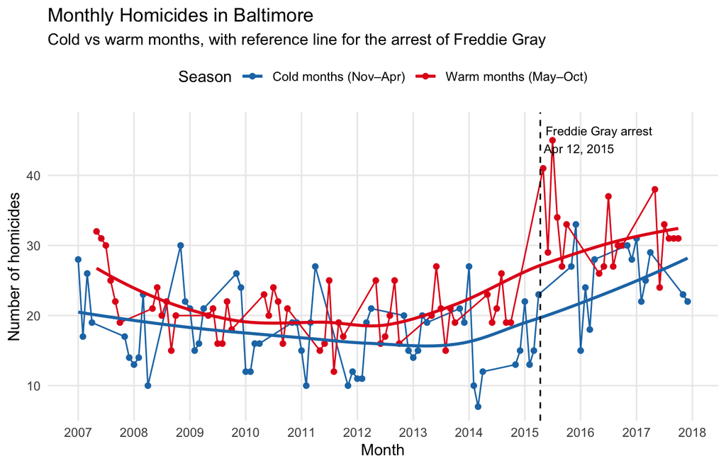

```r
freddie_arrest <- as.Date("2015-04-12")

ggplot2::ggplot(baltimore_monthly,
                ggplot2::aes(x = month, y = homicides, color = season)) +
  ggplot2::geom_line() +
  ggplot2::geom_point(size = 1.5) +
  # smooth line for seasonal / long-term trends
  ggplot2::geom_smooth(se = FALSE, size = 1, linetype = "solid") +
  ggplot2::geom_vline(xintercept = freddie_arrest, linetype = "dashed") +
  ggplot2::annotate(
    "text",
    x = freddie_arrest,
    y = max(baltimore_monthly$homicides, na.rm = TRUE) + 2,
    label = "Freddie Gray arrest\nApr 12, 2015",
    hjust = -0.05,
    vjust = 1,
    size = 3
  ) +
  ggplot2::scale_color_manual(
    values = c(
      "Cold months (Nov–Apr)" = "#1f78b4",
      "Warm months (May–Oct)" = "#e31a1c"
    )
  ) +
  ggplot2::scale_x_date(
    date_breaks = "1 year",
    date_labels = "%Y"
  ) +
  ggplot2::labs(
    title = "Monthly Homicides in Baltimore",
    subtitle = "Cold vs warm months, with reference line for the arrest of Freddie Gray",
    x = "Month",
    y = "Number of homicides",
    color = "Season"
  ) +
  ggplot2::theme_minimal(base_size = 11) +
  ggplot2::theme(
    legend.position = "top",
    panel.grid.minor = ggplot2::element_blank()
  )
```

## # Methods and Interpretation

### 7. Methods summary

Steps included: - Filter Baltimore cases - Convert reported_date to proper Date objects - Aggregate counts to monthly level - Create cold vs warm month indicator - Build monthly time-series plot with smooth and reference line

### 9. Reproducibility notes

This analysis uses only CRAN packages and reads data from `data/homicide-data.csv`.  
Anyone cloning the repository with the same structure can knit the document.